# Sensitivity of RepeatMasker recovery to nesting rate and integrity distribution

Ting-Hsuan Chen

04 November, 2026

This script covers two revision items that reuse the Fig. 5 recovery pipeline:

- **Item 34** (R1#5, R3-minor#16): recovery of nested TE insertions vs. other TEs, and recovery as a function of the nested insertion rate (0% vs. the default random 0-30% vs. 30%).
- **Item 35** (R1#6): sensitivity of recovery to the beta-distribution parameters controlling TE integrity (default alpha = 0.5, beta = 0.7 vs. mostly fragmented 0.5/2 vs. mostly intact 2/0.5).

In the simulator’s GFF, a nested insertion carries `Nest_in=<host>`, and the host TE it lands in is split into two pieces, each carrying `Cut_by=<insert>`. Both pieces keep the host’s whole-element `Integrity`, although each piece is only part of the host, so host pieces are reported separately rather than mixed into the integrity bins of other TEs.

## 1. Load per-locus recovery

## 2. Item 34: nested vs. non-nested recovery in the existing genomes (no new simulation)

Recovery rate by locus category (mean +/- SD across 5 replicates per scenario).

| scenario | category | n_mean | pct_loci_mean | rate_mean | rate_sd |
| --- | --- | --- | --- | --- | --- |
| scenario1 | other | 159887 | 86.65 | 0.861 | 0.004 |
| scenario1 | host piece | 16420 | 8.90 | 0.800 | 0.006 |
| scenario1 | nested insert | 8210 | 4.45 | 0.903 | 0.006 |
| scenario2 | other | 159253 | 86.23 | 0.691 | 0.007 |
| scenario2 | host piece | 16946 | 9.18 | 0.634 | 0.011 |
| scenario2 | nested insert | 8473 | 4.59 | 0.741 | 0.007 |
| scenario3 | other | 159199 | 86.24 | 0.849 | 0.003 |
| scenario3 | host piece | 16942 | 9.17 | 0.777 | 0.004 |
| scenario3 | nested insert | 8471 | 4.59 | 0.898 | 0.006 |
| scenario4 | other | 161710 | 85.53 | 0.929 | 0.004 |
| scenario4 | host piece | 18246 | 9.65 | 0.865 | 0.006 |
| scenario4 | nested insert | 9123 | 4.82 | 0.961 | 0.006 |

Saved file name: nested_category_recovery_existing.csv

Recovery by identity bin, per category (pooled rate within each replicate, mean +/- SD across replicates). Identity is comparable across categories; integrity is not (host pieces carry the whole host’s integrity), so it is not used to stratify here.

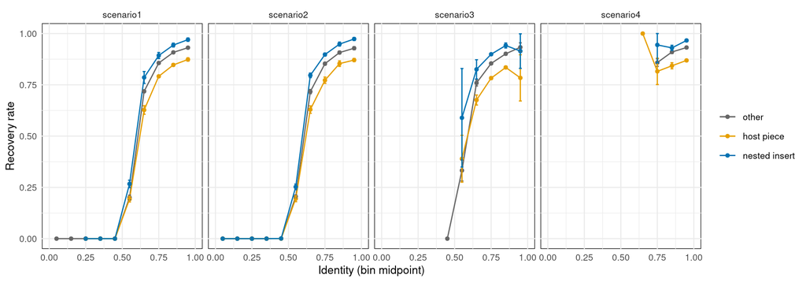

Saved file name: nested_category_recovery_by_identity.png

## 3. Item 34: nesting-rate sweep (scenario 1, replicates 1-3)

`nest` is the percentage of each LTR/Copia and LTR/Gypsy family’s copies inserted as nested insertions (total copy number is unchanged). In the A. thaliana library, Gypsy elements are labelled LTR/Ty3, so only Copia families are nested here.

Overall recovery by nesting setting (mean +/- SD of 3 paired replicates; difference to the baseline within each replicate).

| config | pct_nested_insert | pct_host_piece | rate_mean | rate_sd | diff_vs_baseline_mean | diff_vs_baseline_sd |
| --- | --- | --- | --- | --- | --- | --- |
| nest0 | 0.0000 | 0.0000 | 0.8636 | 0.0047 | 0.0070 | 9e-04 |
| baseline | 4.4482 | 8.8964 | 0.8566 | 0.0045 | 0.0000 | 0e+00 |
| nest30 | 8.5190 | 17.0380 | 0.8499 | 0.0043 | -0.0067 | 7e-04 |

Recovery by locus category and nesting setting (mean +/- SD of 3 replicates).

| config | category | rate_mean | rate_sd |
| --- | --- | --- | --- |
| nest0 | other | 0.8636 | 0.0047 |
| baseline | other | 0.8600 | 0.0048 |
| baseline | host piece | 0.7992 | 0.0041 |
| baseline | nested insert | 0.9047 | 0.0028 |
| nest30 | other | 0.8557 | 0.0043 |
| nest30 | host piece | 0.7970 | 0.0052 |
| nest30 | nested insert | 0.9044 | 0.0027 |

Saved file names: nest_sweep_per_replicate.csv, nest_sweep_summary.csv, nest_sweep_by_category.csv

## 4. Item 35: integrity (beta distribution) sweep (scenario 1, replicates 1-3)

Recovery depends on identity and integrity (Fig. 5), so changing alpha/beta should change overall recovery mainly by changing how many copies fall into each integrity bin, especially below 0.1. The re-weighting check below tests this: it predicts each config’s overall recovery from the baseline’s per-bin (identity x integrity) recovery rates weighted by the config’s own bin counts, and compares the prediction with the observed rate. Host pieces are excluded from the re-weighting because their integrity label is the whole host’s.

Overall recovery (host pieces excluded) by beta distribution (mean +/- SD of 3 paired replicates), and recovery predicted from baseline per-bin rates re-weighted by each config’s bin counts.

| config | label | mean_integrity | pct_integrity_lt_0.1 | rate_mean | rate_sd | diff_vs_baseline_mean | diff_vs_baseline_sd | predicted_rate_mean | pct_loci_without_baseline_bin |
| --- | --- | --- | --- | --- | --- | --- | --- | --- | --- |
| fragheavy | beta(0.5, 2) | 0.2068 | 43.4179 | 0.7953 | 0.0058 | -0.0668 | 0.0016 | 0.7990 | 0.0012 |
| baseline | beta(0.5, 0.7) default | 0.4193 | 24.1429 | 0.8622 | 0.0043 | 0.0000 | 0.0000 | 0.8622 | 0.0000 |
| intactheavy | beta(2, 0.5) | 0.7975 | 0.3221 | 0.9450 | 0.0025 | 0.0828 | 0.0019 | 0.9438 | 0.0002 |

Saved file names: beta_sweep_per_replicate.csv, beta_sweep_summary.csv

Integrity distribution of each config (left) and recovery by integrity bin (right; pooled rate within each replicate, mean +/- SD). If the per-bin recovery curves overlap, alpha/beta change overall recovery only through the integrity distribution.

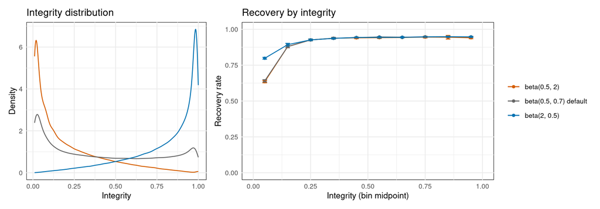

Saved file name: beta_sweep_integrity_recovery.png

## 5. Notes

- The sweep is one-factor-at-a-time around scenario 1 with 3 paired replicates per setting; it shows the direction and size of each parameter’s effect, not a full response surface.
- Recovery uses the same 80% reciprocal-overlap criterion as Fig. 5. Host pieces are evaluated as separate loci, so a host split by a nested insertion is counted as recovered only for the pieces RepeatMasker annotates with >= 80% reciprocal overlap.